# California Houses price predection

## Framing the Problem

The goal of this report is to analyze the relationship between various socioeconomic factors and median house values in a given dataset. We aim to understand how specific independent variables, such as median income, population, and number of households, influence the dependent variable, which is the median house value.

```python
import pandas as pd
import seaborn as sns
from sklearn import linear_model

housing = pd.read_csv("housing.csv")
from sklearn.metrics import mean_squared_error, mean_absolute_error
```

```python
housing.describe()
```

|  | longitude | latitude | housing_median_age | total_rooms | total_bedrooms | population | households | median_income | median_house_value |
| --- | --- | --- | --- | --- | --- | --- | --- | --- | --- |
| count | 20640.000000 | 20640.000000 | 20640.000000 | 20640.000000 | 20433.000000 | 20640.000000 | 20640.000000 | 20640.000000 | 20640.000000 |
| mean | -119.569704 | 35.631861 | 28.639486 | 2635.763081 | 537.870553 | 1425.476744 | 499.539680 | 3.870671 | 206855.816909 |
| std | 2.003532 | 2.135952 | 12.585558 | 2181.615252 | 421.385070 | 1132.462122 | 382.329753 | 1.899822 | 115395.615874 |
| min | -124.350000 | 32.540000 | 1.000000 | 2.000000 | 1.000000 | 3.000000 | 1.000000 | 0.499900 | 14999.000000 |
| 25% | -121.800000 | 33.930000 | 18.000000 | 1447.750000 | 296.000000 | 787.000000 | 280.000000 | 2.563400 | 119600.000000 |
| 50% | -118.490000 | 34.260000 | 29.000000 | 2127.000000 | 435.000000 | 1166.000000 | 409.000000 | 3.534800 | 179700.000000 |
| 75% | -118.010000 | 37.710000 | 37.000000 | 3148.000000 | 647.000000 | 1725.000000 | 605.000000 | 4.743250 | 264725.000000 |
| max | -114.310000 | 41.950000 | 52.000000 | 39320.000000 | 6445.000000 | 35682.000000 | 6082.000000 | 15.000100 | 500001.000000 |

**Proccesing data:to remove noise and outliers**

```python
housing_preprocessed = housing[housing.median_house_value != 500001]
```

**Creating Seaborn scatter plot of median house value vs. median income**

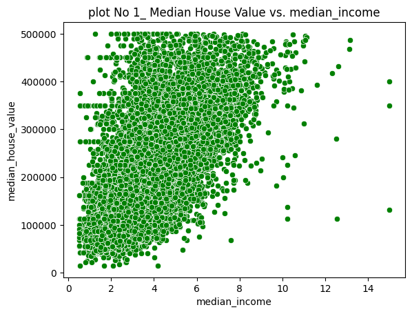

```python
sns.scatterplot(x="median_income", y="median_house_value",data=housing_preprocessed, color="green")
plt.title("plot No 1_ Median House Value vs. median_income")
```

Create a linear regression object,,

running linear regressions between median house value vs. median income

```python
model=linear_model.LinearRegression()
model.fit(X=housing_preprocessed[["median_income"]], y=housing_preprocessed[["median_house_value"]])
```

```
LinearRegression()
```

print the intercept and slope, the Mean Squared Error-the loss (MSE) and Mean Absolute Error(MAE) between median house value and median income

```python
# print coefficients and Intercept
from sklearn.metrics import mean_squared_error, mean_absolute_error
print(f"Intercept: {model.intercept_}")
print(f"Coefficients: {model.coef_}")
# print the MSE and MAE on the train set
print(f"Mean squared error: {mean_squared_error(housing_preprocessed[['median_house_value']], model.predict(housing_preprocessed[['median_income']]))}")
print(f"Mean absolute error: {mean_absolute_error(housing_preprocessed[['median_house_value']], model.predict(housing_preprocessed[['median_income']]))}")
```

```
Intercept: [45456.99678232]
Coefficients: [[39987.01206231]]
Mean squared error: 5604611138.03709
Mean absolute error: 56837.261160385766
```

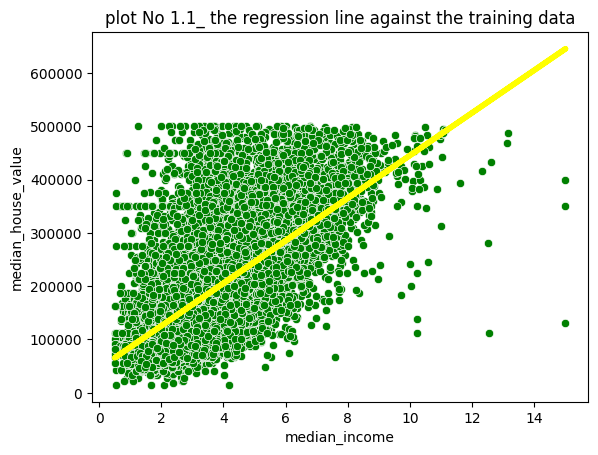

```python
# plot the regression line against the training data
import matplotlib.pyplot as plt

sns.scatterplot(x="median_income",y="median_house_value", data=housing_preprocessed, color="green")
plt.plot(housing_preprocessed[["median_income"]], model.predict(housing_preprocessed[["median_income"]]), color="yellow",linewidth=4)
plt.title("plot No 1.1_ the regression line against the training data")
plt.show()
```

## median house value vs. population:

**Creating Seaborn scatter plot of median house value vs. population**

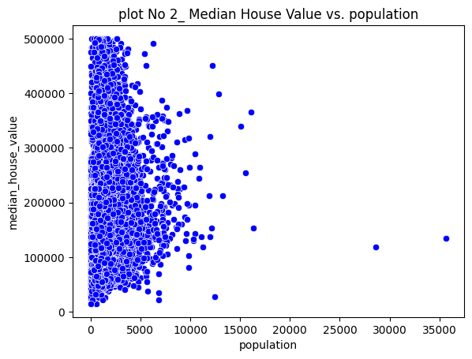

```python
import pandas as pd
import seaborn as sns
from sklearn import linear_model
import matplotlib.pyplot as plt

sns.scatterplot(x="population", y="median_house_value",data=housing_preprocessed, color="blue")
plt.title("plot No 2_ Median House Value vs. population")
```

running linear regressions between median house value vs. popluation

```python
model1=linear_model.LinearRegression()              #making this model as variable and gave it a name so will not be confused with other models in this page
model1.fit(X=housing[["population"]], y=housing[["median_house_value"]])
```

```
LinearRegression()
```

print the intercept and slope, the Mean Squared Error-the loss (MSE) and Mean Absolute Error(MAE) between median house value and popluation

```python
# print coefficients and Intercept
from sklearn.metrics import mean_squared_error, mean_absolute_error
print(f"Intercept: {model1.intercept_}")
print(f"Coefficients: {model1.coef_}")
# print the MSE and MAE on the train set
print(f"Mean squared error: {mean_squared_error(housing_preprocessed[['median_house_value']], model1.predict(housing_preprocessed[['population']]))}")
print(f"Mean absolute error: {mean_absolute_error(housing_preprocessed[['median_house_value']], model1.predict(housing_preprocessed[['population']]))}")
```

```
Intercept: [210436.26207627]
Coefficients: [[-2.51175277]]
Mean squared error: 9767638847.135561
Mean absolute error: 81285.26575981296
```

Plotting the resulting line on top of the scatter data median house value and population

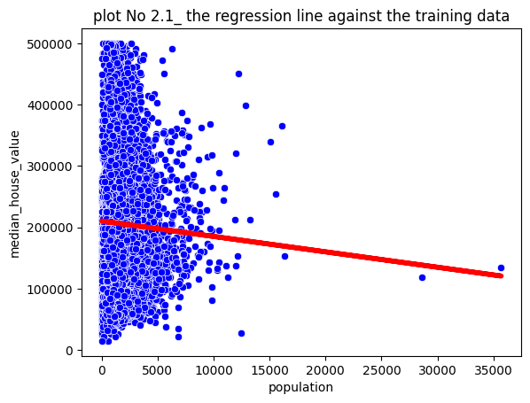

```python
# plot the regression line against the training data
import matplotlib.pyplot as plt


sns.scatterplot(x="population",y="median_house_value", data=housing_preprocessed, color="blue" )
plt.plot(housing_preprocessed[["population"]], model1.predict(housing_preprocessed[["population"]]),color="red", linewidth=4)
plt.title("plot No 2.1_ the regression line against the training data")
plt.show()
```

## median house value vs. number of households

**Creating Seaborn scatter plot of median house value vs. number of households**

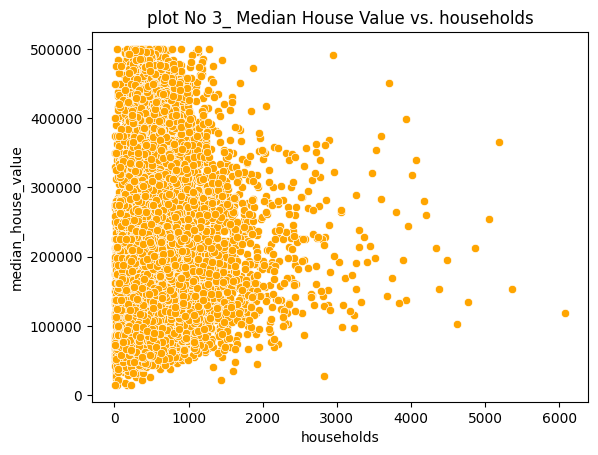

```python
import matplotlib.pyplot as plt
sns.scatterplot(x="households", y="median_house_value",data=housing_preprocessed, color="orange")
plt.title("plot No 3_ Median House Value vs. households")
```

running linear regressions between median house value vs. number of householders

```python
model2=linear_model.LinearRegression()
model2.fit(X=housing[["households"]], y=housing[["median_house_value"]])
```

```
LinearRegression()
```

print the intercept and slope, the Mean Squared Error-the loss (MSE) and Mean Absolute Error(MAE) between median house value and number of house hold

```python
# print coefficients and Intercept
from sklearn.metrics import mean_squared_error, mean_absolute_error
print(f"Intercept: {model2.intercept_}")
print(f"Coefficients: {model2.coef_}")
# print the MSE and MAE on the train set
print(f"Mean squared error: {mean_squared_error(housing_preprocessed[['median_house_value']], model2.predict(housing_preprocessed[['households']]))}")
print(f"Mean absolute error: {mean_absolute_error(housing_preprocessed[['median_house_value']], model2.predict(housing_preprocessed[['households']]))}")
```

```
Intercept: [196928.57716233]
Coefficients: [[19.87277516]]
Mean squared error: 9671490747.131296
Mean absolute error: 80845.73337070213
```

Plotting the resulting line on top of the scatter data median house value and number of households

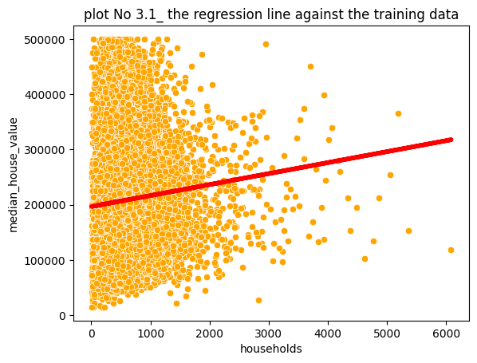

```python
# plot the regression line against the training data
import matplotlib.pyplot as plt


sns.scatterplot(x="households",y="median_house_value", data=housing_preprocessed, color="orange" )
plt.plot(housing_preprocessed[["households"]], model2.predict(housing_preprocessed[["households"]]),color="red", linewidth=4)
plt.title("plot No 3.1_ the regression line against the training data")
plt.show()
```

| Model | Intercept | Slope | MSE | MAE |
| --- | --- | --- | --- | --- |
| Median Income vs. House Value | 45456.99678232 | 39987.01206231 | 5604611138.03709 | 56837.261160385766 |
| Population vs. House Value | 210436.26207627 | -2.51175277 | 9767638847.135561 | 81285.26575981296 |
| Households vs. House Value | 196928.57716233 | 19.87277516 | 9671490747.131296 | 80845.73337070213 |

## Conclusion:

However, the models that consider population and households in relation to house value don't perform as well. They have higher errors, indicating that they might not be as good at predicting house values.Additionally, if we look at Plot No. 2.1, we can see that the points are quite scattered and not closely aligned with the line. In an attempt to improve the accuracy of the line, I processed the data and removed some noise, resulting in Plot No. 2.2. However, even after this adjustment, the line still doesn't seem to provide a satisfactory fit to the data.

Appendix removing noise from median_house_value vs poluation plot:

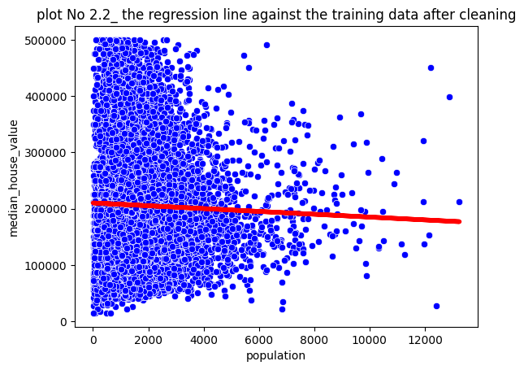

```python
housing_cleaning= housing_preprocessed[housing_preprocessed.population <15000]
sns.scatterplot(x="population",y="median_house_value", data=housing_cleaning, color="blue" )
plt.plot(housing_cleaning[["population"]], model1.predict(housing_cleaning[["population"]]),color="red", linewidth=4)
plt.title("plot No 2.2_ the regression line against the training data after cleaning")
plt.show()
```